# Part II - Probability of being Transported

## by Babajide Alao

## Investigation Overview

> During the cause of investigating this dataset, features that increase the probability of being transported to a passeners destination was my main focus.This study can be used for predictive analysis upon further analysis. My main focus was on Age, CryoSleep,Homeplanet and Destination variables

## Dataset Overview

> This data set contains 8,693 rows with each row being an information about each passengers and 14 variables which describes the passengers. The dataset contains features like PassengerId, HomePlanet, Cabin, Destination, Transported, and many others. During the cleaning stage, I dropped a few columns which I felt would not in any way affect the analysis. Features like: PasssengerId and Name of Passenger

## Destination Of Passengers

> A very large percentage passengers are heading to TRAPPIST-1e.

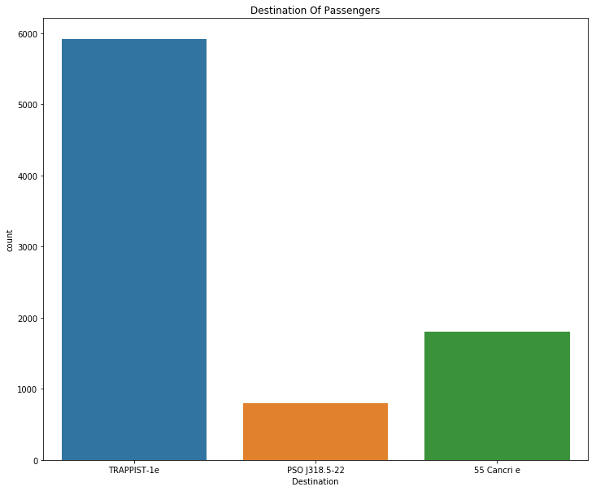

## Home Planet of Transported Passengers

> Majority of the passengers from Europa Got transported to their destination

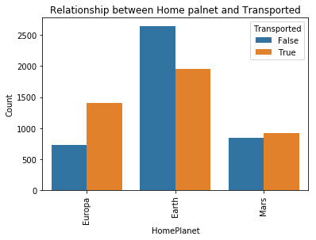

## Relationship between Age Range and Transported

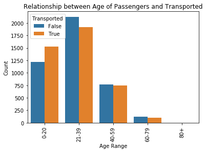

## Relationship between CryoSleep and Transported

> Majority of the Passengers that opted to sleep throughout the voyage was transported

```
Text(0.5,1,'Relationship between Cryosleep and Transported')
```

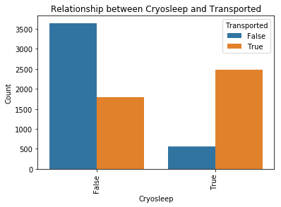

### Submission

   ```
   zip -r my_project.zip .
   ```

   The command abobve will ZIP every file present in your /home/workspace directory. Next, you can download the zip to your local, and follow the instructions on the last page of this project lesson.